# Aula 3 Regressão

18/08/2022

Para os exercícios a seguir: (1) efetue a regressão linear; (2) encontre os coeficientes de regressão; (3) plote o gráfico de dispersão e a reta de regressão; (4) desenvolva os itens solicitados.

## Exercício 1

O conjunto de dados **cars**, do pacote **datasets**, registra a distância (dist) percorrida até a parada total de um determinado carro e a velocidade (speed), em milhas por hora, na qual o freio foi pressionado.

1. Estime o valor esperado da distância de frenagem para as velocidades de 5, 10, 14, 23 e 30 mph.
2. Encontre o intercepto quando a velocidade é deslocada do seu valor médio.
3. Encontre a inclinação quando a unidade da velocidade é quilômetros por hora (1 mph = 1,61 km/h).

```r
# regressão linear
regressao = lm(cars$dist ~ cars$speed)

# coeficientes de regressão
regressao$coefficients
```

```
## (Intercept)  cars$speed
##  -17.579095    3.932409
```

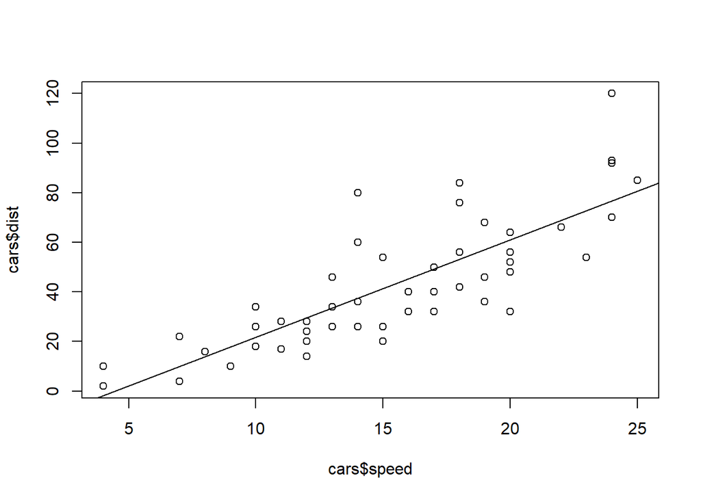

```r
# gráfico de dispersão e reta de regressão
plot(cars$speed, cars$dist)
abline(regressao)
```

```r
# questões
beta0 = regressao$coefficients['(Intercept)']
beta1 = regressao$coefficients['cars$speed']
# para a velocidade de 5, 10, 14, 23 e 30
beta0 + c(5, 10, 14, 23, 30)*beta1
```

```
## [1]   2.082949  21.744993  37.474628  72.866307 100.393168
```

```r
# intercepto - speed valor médio
beta0 + beta1*mean(cars$speed)
```

```
## (Intercept)
##       42.98
```

```r
# inclinação
beta1/1.61
```

```
## cars$speed
##    2.44249
```

## Exercício 2

O conjunto de dados airquality, do pacote datasets, registra leituras diárias da qualidade do ar em Nova York no ano de 1973. Desconsidere os registros em que não há valor observado (NA) e desenvolva os seguintes itens:

1. Verifique, por meio da regressão linear, a variação da concentração de Ozônio em função da radiação solar.
2. Estime a concentração de Ozônio esperada para os seguintes níveis de radiação (lang): 10, 100, 200, 300.
3. Verifique, por meio da regressão linear, a variação da concentração de Ozônio em função da velocidade do vento.
4. Estime a concentração de Ozônio esperada para as seguintes velocidades do vento (mph): 1.5, 3.7, 10, 15.3, 22.

```r
head(airquality)
```

```
##   Ozone Solar.R Wind Temp Month Day
## 1    41     190  7.4   67     5   1
## 2    36     118  8.0   72     5   2
## 3    12     149 12.6   74     5   3
## 4    18     313 11.5   62     5   4
## 5    NA      NA 14.3   56     5   5
## 6    28      NA 14.9   66     5   6
```

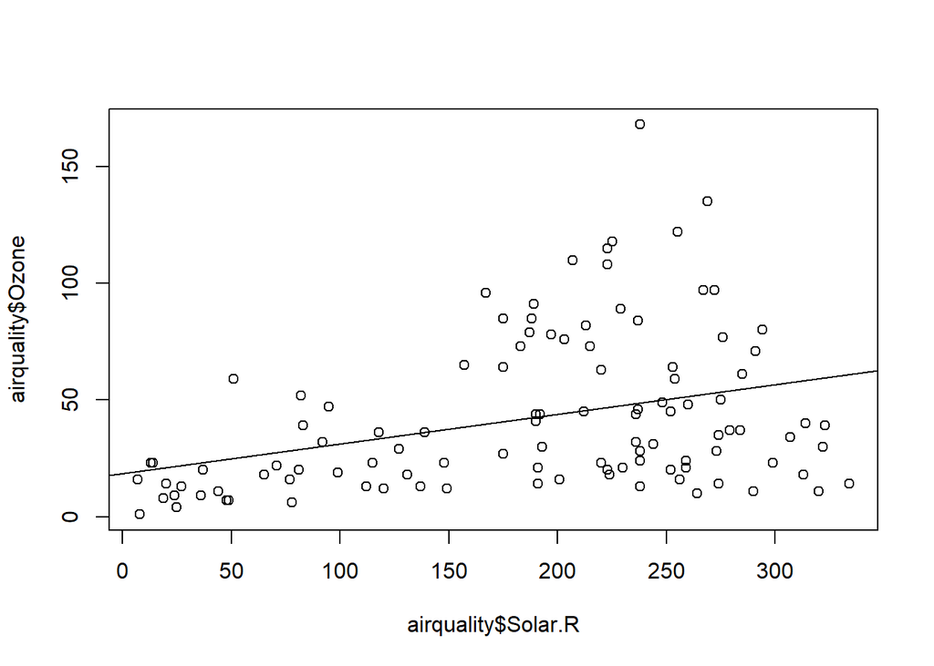

```r
# 1
regressao = lm(airquality$Ozone ~ airquality$Solar.R)
plot(airquality$Solar.R, airquality$Ozone)
abline(regressao)
```

```r
# 2
beta0 = regressao$coefficients['(Intercept)']
beta1 = regressao$coefficients['airquality$Solar.R']

beta0 + c(10, 100, 200, 300)*beta1
```

```
## [1] 19.87038 31.31525 44.03178 56.74831
```

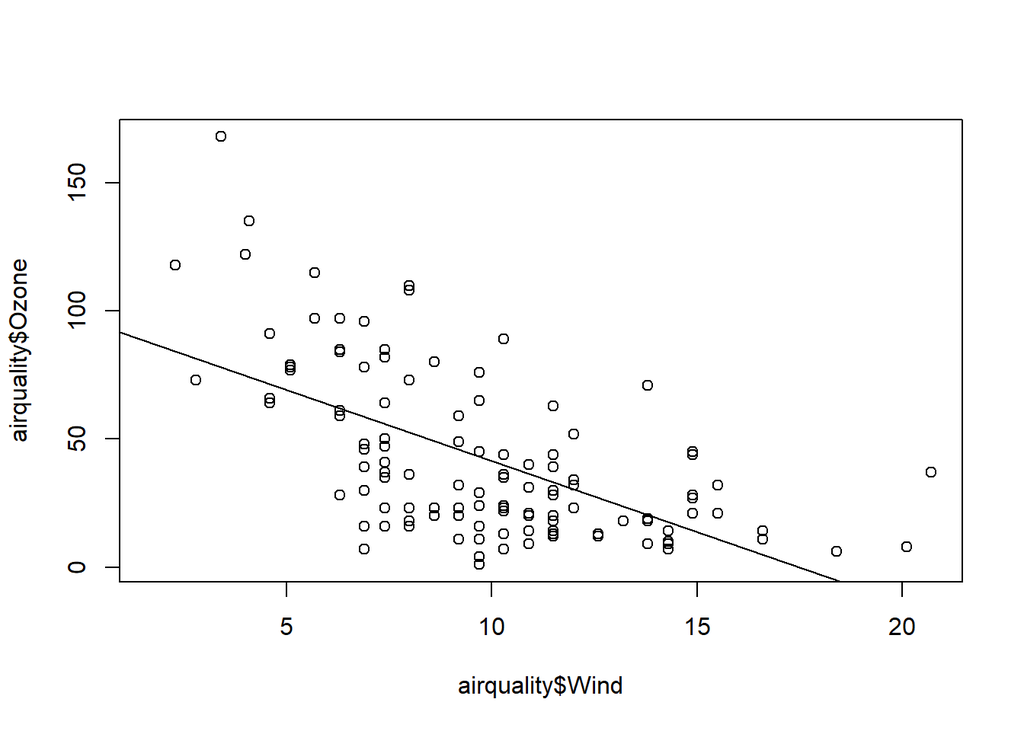

```r
# 3
regressao = lm(airquality$Ozone ~ airquality$Wind)
plot(airquality$Wind, airquality$Ozone)
abline(regressao)
```

```r
beta0 = regressao$coefficients['(Intercept)']
beta1 = regressao$coefficients['airquality$Wind']
# 4

beta0 + c(1.5, 3.7, 10, 15.3, 22)*beta1
```

```
## [1]  88.54651  76.33448  41.36367  11.94377 -25.24741
```

## Exercício 3

O arquivo Eleicoes2014, disponível na pasta do laboratório, contém dados da eleição de 2014 para Deputado Federal.

```r
e2014 <- read.csv2("Eleicoes2014.csv")

head(e2014)
```

```
##   Sequencial Regiao   UF Partido   Nr                         Candidato
## 1          1     SE   SP      PV 4344           ROBERTO ALVES DE LUCENA
## 2          2     SE   SP      PR 2222 FRANCISCO EVERARDO OLIVEIRA SILVA
## 3          3     SE   SP      PT 1390            VICENTE PAULO DA SILVA
## 4          4     SE   SP     DEM 2577                ADRIANO ELI CORREA
## 5          5     SE   SP    PSDB 4544   ANTONIO FLORIANO PEREIRA PESARO
## 6          6     SE <NA>      PT 1322          ARLINDO CHIGNALIA JUNIOR
##      Nome.eleitoral Idade         Situacao      Sexo  QE base.oposicao.neutro
## 1 ROBERTO DE LUCENA    48    ELEITO POR QP MASCULINO Nao                    O
## 2          TIRIRICA    49    ELEITO POR QP MASCULINO Sim                    B
## 3        VICENTINHO    58    ELEITO POR QP MASCULINO Nao                    B
## 4  ELI CORREA FILHO    38    ELEITO POR QP MASCULINO Nao                    O
## 5   FLORIANO PESARO    46 ELEITO POR M\220DIA MASCULINO Nao                    O
## 6 ARLINDO CHINAGLIA    64    ELEITO POR QP MASCULINO Nao                    B
##   Grau.de.instrucao                                                 Ocupacao
## 1 SUPERIOR COMPLETO                                                 DEPUTADO
## 2      LE E ESCREVE                                                 DEPUTADO
## 3 SUPERIOR COMPLETO                                                   OUTROS
## 4 SUPERIOR COMPLETO LOCUTOR E COMENTARISTA DE RADIO E TELEVISÇO E RADIALISTA
## 5 SUPERIOR COMPLETO                                                 VEREADOR
## 6 SUPERIOR COMPLETO                                                   M\220DICO
##   Eleito.em.2010 Receitas.em.2014 Nominais Custo.Voto
## 1            Sim        316915.53    67191         NA
## 2            Sim           983590  1016796         NA
## 3            Sim       1440155.23    89001         NA
## 4            Sim       1107579.77   134138         NA
## 5            Nao       2572639.07   113949         NA
## 6            Sim       4834358.25   135772         NA
```

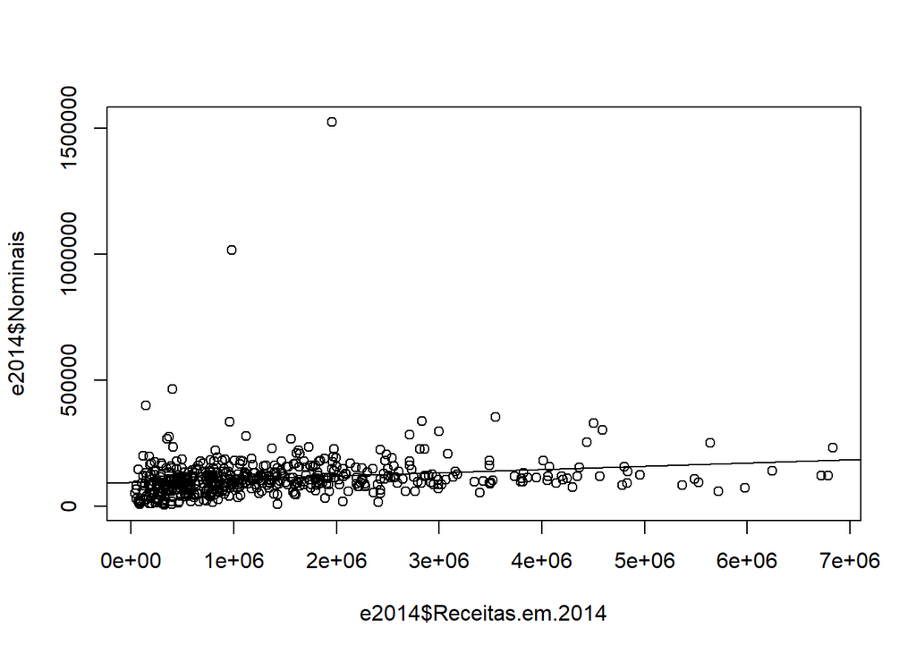

```r
e2014$Receitas.em.2014 = as.numeric(e2014$Receitas.em.2014)

# 1
regressao = lm(e2014$Nominais ~ e2014$Receitas.em.2014)
plot(e2014$Receitas.em.2014, e2014$Nominais)
abline(regressao)
```

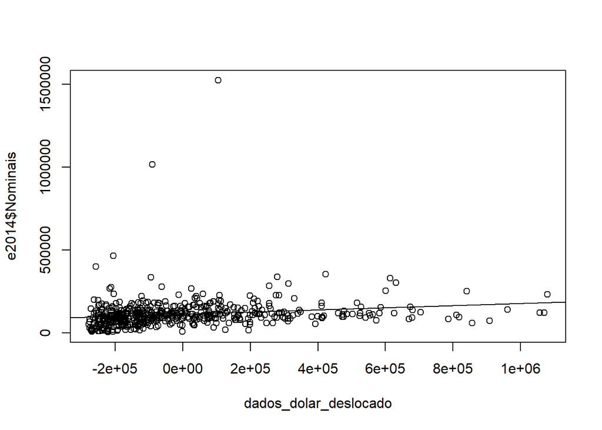

```r
# 2
dados_dolar_deslocado = I( 0.2*(e2014$Receitas.em.2014 - mean(e2014$Receitas.em.2014)))
regressao = lm(e2014$Nominais ~ dados_dolar_deslocado)
plot(dados_dolar_deslocado, e2014$Nominais)
abline(regressao)
```